# Small variant detection with short read sequencing (Part II: Variant Identification and Annotation)

*INRAe-IFB-INSERM Bioinformatics School 2026*

- Maria BERNARD - INRAE

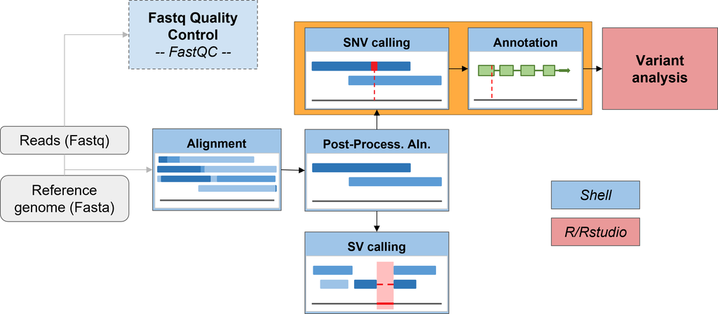

Check that you are still in your `atelier_variant/TP_small_variants` folder.

```bash
pwd
```

```
/shared/projects/2621_eb3in1_2026/atelier_variant/TP_small_variants
```

## I - Introduction to Variant Calling

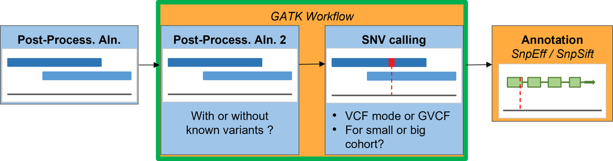

### 1. Goal of variant calling

Variant calling is the automated detection of variants (SNVs, small Indels) from a file containing aligned sequencing data (BAM file).  
The goal is to produce a VCF file (more details on the [VCF](https://en.wikipedia.org/wiki/Variant_Call_Format) format).

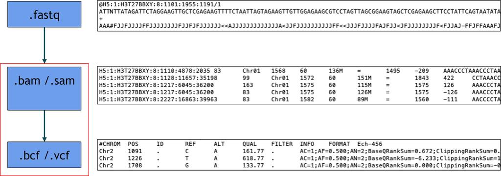

For each position of the reference genome, the algorithms (the "variant callers") take into account the counts of each allele present in the reads aligned at that position, as well as the various scores (base quality, mapping quality), to make a hypothesis about the presence of a variant and about the most likely genotype.

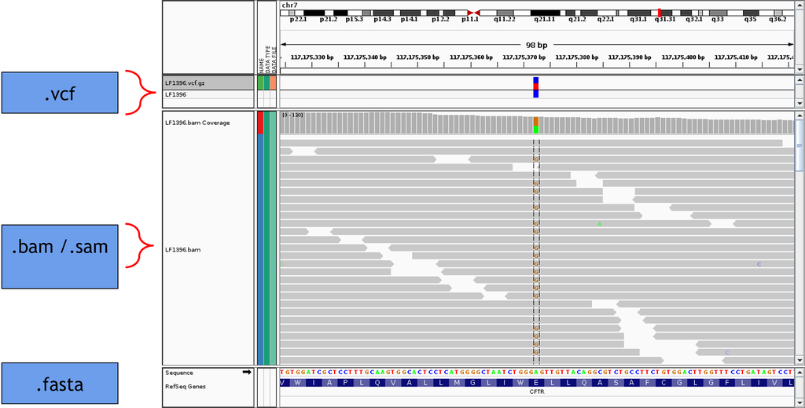

Sounds simple, but it actually involves several difficulties.

### 2. Choosing the variant caller

The choice of variant caller depends on the biological question / the organism studied.  
Commonly found in the literature:

- [GATK Haplotype Caller](https://gatk.broadinstitute.org/hc/en-us/articles/30332006386459-HaplotypeCaller) or [GATK Mutect2](https://gatk.broadinstitute.org/hc/en-us/articles/30332058799003-Mutect2) (dedicated to tumour or mitochondrial genomes)
- [Samtools mpileup](https://www.htslib.org/doc/samtools-mpileup.html) followed by [Bcftools](https://samtools.github.io/bcftools/bcftools.html) or [VarScan2](http://dkoboldt.github.io/varscan/) (cancer-oriented)
- [FreeBayes](https://github.com/freebayes/freebayes)
- DiscoSnp (variant calling without a reference genome)
- [DeepVariant](https://github.com/google/deepvariant): variant calling using deep learning (complex regions, low depth)
- [Snippy](https://github.com/tseemann/snippy): dedicated to haploid organisms.

⚠️Warning:  
No tool is perfect: the quality of the calling depends on the whole pipeline, the data analysed, and the parameters used to filter the results.

91.7% concordance between Freebayes, Samtools, GATK HC ([Hwang et al., 2015](https://doi.org/10.1038/srep17875)).  
Other analyses show lower rates, 70% ([O’Rawe et al., Genome Med, 2013](https://doi.org/10.1186/gm432)), 57% ([Cornish et al., BioMed, 2015](https://doi.org/10.1155/2015/456479)).

[figure not shown]

### 3. Difficulties / Limitations

Many false positive variants can arise from the previous steps:

- Read errors during “BaseCalling”
- Artefacts related to the sequencing technology (PacBio, HiSeq, NextSeq, … )
- Artefacts from PCR cycles during sample preparation
- Alignment difficulties (repeated DNA regions)

**Summary**

- Variant detection identifies SNVs and small Indels from an alignment file in BAM format.
- Many tools exist for variant detection; their efficiency depends on many parameters (mapping, data quality, result filtering parameters).

## II - Variant calling with the GATK suite (Genome Analysis ToolKit)

[GATK](https://gatk.broadinstitute.org) is a suite of tools developed by the Broad Institute:

- It comes with good documentation including various best Practices.

⚠️Warning:  
The documentation may evolve a little more slowly than the versions, and some options are only documented in the command-line help.

- It includes a local reassembly and realignment step for indels to better distinguish error sources from true variants.
- It uses a Bayesian algorithm (statistical models to estimate the probability of each possible genotype, taking into account the various biases that can introduce noise into the data).
- It supports the analysis of multiple samples in several batches (gVCF format).

Let's load the GATK module and create a new directory for the results.

```bash
module load gatk4/4.6.1.0
mkdir -p Results/Variant_calling/
```

Reminder of the files available for our sample 40995 (processed step by step so far)

```bash
ls -lh Results/Alignment/milca_40995*
```

```
-rw-rw----+ 1 mbernard mbernard 620K Aug 21 13:56 Results/Alignment/milca_40995_md.bai
-rw-rw----+ 1 mbernard mbernard 506M Aug 21 13:56 Results/Alignment/milca_40995_md.bam
-rw-rw----+ 1 mbernard mbernard 4.3K Aug 21 13:56 Results/Alignment/milca_40995_metrics_md.txt
```

### 1. Genome indexing

Like other callers, GATK needs indexes of the reference genome to work:

- `.fai` : the fasta index is a general-purpose index required by many different tools
- `.dict` : the sequence dictionary is specific to the GATK suite.

**Creating the fasta index: .fai (samtools)**

Identify and load the samtools module

```bash
module load samtools/1.23.1
```

Display the help of the `samtools faidx` command and apply it to our reference genome (fasta file).

```bash
samtools faidx data/genome/Bos_taurus_GCF_002263795.3_ARS-UCD2.0_chr2_chr6.fasta
```

```bash
ls -lhtr data/genome/
```

```
total 1.7G
-rw-r-----+ 1 mbernard mbernard 247M Jul 31 16:33 Bos_taurus_GCF_002263795.3_ARS-UCD2.0_chr2_chr6.fasta
-rw-r-----+ 1 mbernard mbernard  50M Jul 31 16:33 Bos_taurus_GCF_002263795.3_ARS-UCD2.0_chr2_chr6.gff
-rw-r-----+ 1 mbernard mbernard  19M Aug 14 09:33 Bos_taurus_GCF_002263795.3_ARS-UCD2.0_chr2_chr6_known_indels.vcf.gz
-rw-r-----+ 1 mbernard mbernard 140K Aug 14 09:33 Bos_taurus_GCF_002263795.3_ARS-UCD2.0_chr2_chr6_known_indels.vcf.gz.tbi
-rw-r-----+ 1 mbernard mbernard  90M Aug 14 09:33 Bos_taurus_GCF_002263795.3_ARS-UCD2.0_chr2_chr6_known_snps.vcf.gz
-rw-r-----+ 1 mbernard mbernard 181K Aug 14 09:33 Bos_taurus_GCF_002263795.3_ARS-UCD2.0_chr2_chr6_known_snps.vcf.gz.tbi
-rw-rw----+ 1 mbernard mbernard  61M Aug 21 12:58 Bos_taurus_GCF_002263795.3_ARS-UCD2.0_chr2_chr6.fasta.pac
-rw-rw----+ 1 mbernard mbernard   94 Aug 21 12:58 Bos_taurus_GCF_002263795.3_ARS-UCD2.0_chr2_chr6.fasta.ann
-rw-rw----+ 1 mbernard mbernard  255 Aug 21 12:58 Bos_taurus_GCF_002263795.3_ARS-UCD2.0_chr2_chr6.fasta.amb
-rw-rw----+ 1 mbernard mbernard 485M Aug 21 12:58 Bos_taurus_GCF_002263795.3_ARS-UCD2.0_chr2_chr6.fasta.0123
-rw-rw----+ 1 mbernard mbernard 788M Aug 21 12:59 Bos_taurus_GCF_002263795.3_ARS-UCD2.0_chr2_chr6.fasta.bwt.2bit.64
-rw-rw----+ 1 mbernard mbernard   69 Aug 26 15:30 Bos_taurus_GCF_002263795.3_ARS-UCD2.0_chr2_chr6.fasta.fai
```

```bash
cat data/genome/Bos_taurus_GCF_002263795.3_ARS-UCD2.0_chr2_chr6.fasta.fai
```

```
NC_037329.1	136231102	13	60	61
NC_037333.1	117806340	138501647	60	61
```

**Question**  
Any idea what each column corresponds to?

💡 **Tip**  
Display the first lines of your fasta file

**Creating the sequence dictionary: .dict (GATK)**

Display the help of the `gatk CreateSequenceDictionary` command or refer to the [online documentation](https://gatk.broadinstitute.org/hc/en-us/articles/30331989211419--Tool-Documentation-Index).  
Then apply it to our reference genome (fasta file).

```bash
gatk CreateSequenceDictionary --REFERENCE data/genome/Bos_taurus_GCF_002263795.3_ARS-UCD2.0_chr2_chr6.fasta
```

[output not shown]

```bash
ls -lhrt  data/genome/
```

```
total 1.7G
-rw-r-----+ 1 mbernard mbernard 247M Jul 31 16:33 Bos_taurus_GCF_002263795.3_ARS-UCD2.0_chr2_chr6.fasta
-rw-r-----+ 1 mbernard mbernard  50M Jul 31 16:33 Bos_taurus_GCF_002263795.3_ARS-UCD2.0_chr2_chr6.gff
-rw-r-----+ 1 mbernard mbernard  19M Aug 14 09:33 Bos_taurus_GCF_002263795.3_ARS-UCD2.0_chr2_chr6_known_indels.vcf.gz
-rw-r-----+ 1 mbernard mbernard 140K Aug 14 09:33 Bos_taurus_GCF_002263795.3_ARS-UCD2.0_chr2_chr6_known_indels.vcf.gz.tbi
-rw-r-----+ 1 mbernard mbernard  90M Aug 14 09:33 Bos_taurus_GCF_002263795.3_ARS-UCD2.0_chr2_chr6_known_snps.vcf.gz
-rw-r-----+ 1 mbernard mbernard 181K Aug 14 09:33 Bos_taurus_GCF_002263795.3_ARS-UCD2.0_chr2_chr6_known_snps.vcf.gz.tbi
-rw-rw----+ 1 mbernard mbernard  61M Aug 21 12:58 Bos_taurus_GCF_002263795.3_ARS-UCD2.0_chr2_chr6.fasta.pac
-rw-rw----+ 1 mbernard mbernard   94 Aug 21 12:58 Bos_taurus_GCF_002263795.3_ARS-UCD2.0_chr2_chr6.fasta.ann
-rw-rw----+ 1 mbernard mbernard  255 Aug 21 12:58 Bos_taurus_GCF_002263795.3_ARS-UCD2.0_chr2_chr6.fasta.amb
-rw-rw----+ 1 mbernard mbernard 485M Aug 21 12:58 Bos_taurus_GCF_002263795.3_ARS-UCD2.0_chr2_chr6.fasta.0123
-rw-rw----+ 1 mbernard mbernard 788M Aug 21 12:59 Bos_taurus_GCF_002263795.3_ARS-UCD2.0_chr2_chr6.fasta.bwt.2bit.64
-rw-rw----+ 1 mbernard mbernard   69 Aug 26 15:30 Bos_taurus_GCF_002263795.3_ARS-UCD2.0_chr2_chr6.fasta.fai
-rw-rw----+ 1 mbernard mbernard  435 Aug 26 15:30 Bos_taurus_GCF_002263795.3_ARS-UCD2.0_chr2_chr6.dict
```

```bash
cat data/genome/Bos_taurus_GCF_002263795.3_ARS-UCD2.0_chr2_chr6.dict
```

```
@HD	VN:1.6
@SQ	SN:NC_037329.1	LN:136231102	M5:4d4b5ba33e8e0f5f5a64cf8d29c2d390	UR:file:///shared/projects/2621_eb3in1_2026/atelier_variant/TP_small_variants/data/genome/Bos_taurus_GCF_002263795.3_ARS-UCD2.0_chr2_chr6.fasta
@SQ	SN:NC_037333.1	LN:117806340	M5:a1dccfeeec937701e0aa1601db675987	UR:file:///shared/projects/2621_eb3in1_2026/atelier_variant/TP_small_variants/data/genome/Bos_taurus_GCF_002263795.3_ARS-UCD2.0_chr2_chr6.fasta
```

### 2. BaseRecalibrator

Each base of a sequencing read is associated with a quality score (Phred), meant to reflect the probability that the sequencer made a mistake at that position (`Q30` ↔ 1 error in 1000 bases, `Q20` ↔ 1 error in 100, ...).

In practice, this score "reported" by the sequencer is only an **estimate**, computed by the machine's proprietary software from raw signals (intensities, phasing...). This estimate is systematically biased by technical factors, in particular:

- the **sequencing cycle** (errors often increase towards the end of the read);
- the **dinucleotide context** (some motifs are more error-prone, e.g. homopolymers);
- the **machine/run** used (each platform has its own error signature).

⚠️**Warning**  
Variant callers use these quality scores directly to compute the likelihood of each possible genotype.  
If the reported score is too optimistic (reported quality > actual quality), we risk **overestimating the confidence** in false variations and therefore generating **false positives**.  
Conversely, a score that is too pessimistic can cause true variants to be missed (**false negatives**).

BaseRecalibrator corrects this bias empirically.  
It compares the observed bases at positions of the genome **assumed to be non-variant** (and therefore, in theory, sequencing errors) and builds a statistical model linking reported quality, cycle, sequence context and machine to a recalculated **empirical** quality.  
ApplyBQSR then applies this model to correct the quality scores of each base in the BAM.

ℹ️ **Note**  
So as not to confuse **true** biological variants with sequencing noise, the tool needs to exclude positions already known to be variant: this is the role of the known variant files already available in the `data/genome` directory:

- `Bos_taurus_GCF_002263795.3_ARS-UCD2.0_chr2_chr6_known_snps.vcf.gz`
- `Bos_taurus_GCF_002263795.3_ARS-UCD2.0_chr2_chr6_known_indels.vcf.gz`

Let's create a first sub-directory for the results.

```bash
mkdir -p Results/Variant_calling/BaseRecalibration
```

**BaseRecalibrator**: building the recalibration model

To access the help (often very long) of GATK tools, use:

- in the Terminal `gatk TOOL_NAME --help`
- and/or the [online help](https://gatk.broadinstitute.org/hc/en-us/articles/30332011267355-BaseRecalibrator)

For BaseRecalibrator, the command pattern is:

```
Usage : gatk BaseRecalibrator --java-options '-Xmx8G' \
   --input my_reads.bam \
   --reference reference.fasta \
   --known-sites sites_of_variation.vcf \
   --known-sites another/optional/setOfSitesToMask.vcf \
   --output recal_data.table
```

And the option we are interested in:

- `--intervals,-L` : (saves time here)  
  One or more genomic intervals over which to operate This argument may be specified 0 or more times, format : `Chr:start-stop`

Let's apply this command to our sample milca_40995, using the two known variant sets available in the `data/genome/` folder and on a region of chromosome 2: `NC_037329.1:90000000-91140000`

```bash
 gatk BaseRecalibrator --java-options '-Xmx8G' \
   --input Results/Alignment/milca_40995_md.bam \
   --reference data/genome/Bos_taurus_GCF_002263795.3_ARS-UCD2.0_chr2_chr6.fasta \
   --known-sites data/genome/Bos_taurus_GCF_002263795.3_ARS-UCD2.0_chr2_chr6_known_snps.vcf.gz \
   --known-sites data/genome/Bos_taurus_GCF_002263795.3_ARS-UCD2.0_chr2_chr6_known_indels.vcf.gz \
   --intervals "NC_037329.1:90000000-91140000" \
   --output Results/Variant_calling/BaseRecalibration/milca_40995_recal.table
```

[output not shown]

**ApplyBQSR**: applying the correction to the BAM

To access the help (often very long) of GATK tools, use:

- in the Terminal `gatk TOOL_NAME --help`
- and/or the [online help](https://gatk.broadinstitute.org/hc/en-us/articles/30331973217435-ApplyBQSR)

For ApplyBQSR, the command pattern is:

```
Usage : gatk ApplyBQSR --java-options '-Xmx8G' \
   --reference reference.fasta \
   --input input.bam \
   --bqsr-recal-file recalibration.table \
   --output output_recal.bam
```

And the option we are interested in:

- `--intervals,-L` : (saves time here)  
  One or more genomic intervals over which to operate This argument may be specified 0 or more times, format : `Chr:start-stop`

Let's apply this command to our sample milca_40995 and on a region of chromosome 2: `NC_037329.1:90000000-91140000`

```bash
 gatk ApplyBQSR --java-options '-Xmx8G' \
   --input Results/Alignment/milca_40995_md.bam \
   --reference data/genome/Bos_taurus_GCF_002263795.3_ARS-UCD2.0_chr2_chr6.fasta \
   --bqsr-recal-file Results/Variant_calling/BaseRecalibration/milca_40995_recal.table \
   --intervals "NC_037329.1:90000000-91140000" \
   --output Results/Variant_calling/BaseRecalibration/milca_40995_recal.bam
```

[output not shown]

Let's explore the contents of our results folder

```bash
ls -lrth Results/Variant_calling/BaseRecalibration/
```

```
total 6.4M
-rw-rw----+ 1 mbernard mbernard 355K Aug 26 14:11 milca_40995_recal.table
-rw-rw----+ 1 mbernard mbernard 6.0M Aug 26 14:18 milca_40995_recal.bam
-rw-rw----+ 1 mbernard mbernard  47K Aug 26 14:18 milca_40995_recal.bai
```

💡 **Tip**  
To concretely visualise the effect of this correction (reported quality vs empirical quality curves, before/after), use AnalyzeCovariates.  
See also `Annexe1_Baserecalibration.ipynb` for the case where **no** known variant set is available.

Let's retrieve the results for the other samples

```bash
cp /shared/projects/2621_eb3in1_2026/atelier_variant_correction/TP_small_variants/Results/Variant_calling/BaseRecalibration/* Results/Variant_calling/BaseRecalibration/.
```

### 3. Variant calling and genotyping

### 3.1 Calling strategies

GATK offers two tools for variant calling:

- HaplotypeCaller for germline variants. We will focus on this tool
- Mutect2 for somatic or mitochondrial variants.

For HaplotypeCaller you have several strategies for processing samples to obtain a multi-sample VCF file.

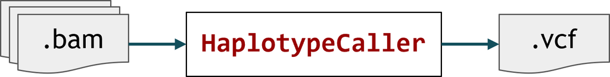

**Direct VCF output**

HaplotypeCaller takes into account all the samples of your cohort at once to identify variants AND genotype the samples.

This strategy is valid if

- you do not expect to add samples to your cohort.
- you have few samples.

ℹ️ **Note**  
This is the historical HaplotypeCaller method, but GVCF mode is now preferred ...

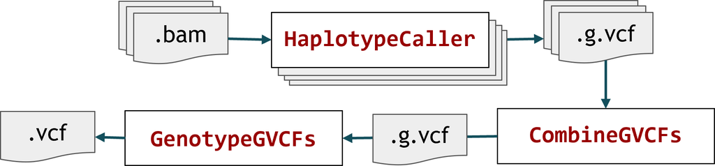

**Indirect output via gVCFs**

Generating gVCFs is useful because:

- it gives the genotype at every position
- it allows the variant panel to evolve as new samples are added, without redoing the calling on the previous samples

ℹ️ **Note**  
This is now the recommended HaplotypeCaller method.

This 3-step procedure is suitable if you have few samples and/or you work on a small genome.

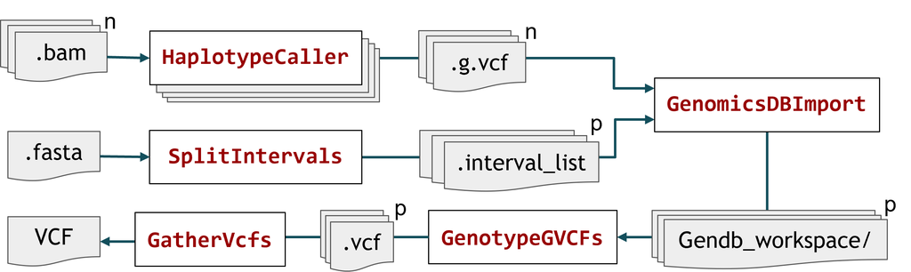

**Indirect output via gVCF and GenomicDBs**

Here we keep the advantages of gVCFs while optimising computing resources.

This 5-step procedure is suitable for projects with a large number of samples and/or on a large genome.

💡 **Tip**  
You will find the details of the 5-step procedure in Annexe2_GenomicsDB.ipynb for the analysis of a large genome and/or a large cohort.

To access the help (often very long) of GATK tools, use:

- in the Terminal `gatk TOOL_NAME --help`
- and/or the [online help](https://gatk.broadinstitute.org/hc/en-us/articles/30332006386459-HaplotypeCaller)

For HaplotypeCaller, the command pattern is:

```
Usage : gatk HaplotypeCaller --java-options '-Xmx8G' \
   --input input.bam [--input input2.bam] \
   --reference reference.fasta \
   --output output.vcf or output.g.vcf
```

HaplotypeCaller offers a great many options, but default values already exist for them and are valid in the vast majority of cases.  
We will use the default values, but we recommend that you specify them in your command line so that you never forget to check them.

Here is the list of the main options:

- `--base-quality-score-threshold` : Default value: 18.  
  Base qualities below this threshold will be reduced to the minimum (6)
- `--min-base-quality-score,-mbq` : Default value: 10.  
  Minimum base quality required to consider a base for calling.

ℹ️ **Note**  
These two options work together. The first transforms the qualities, the second is a threshold for consideration in the calling.  
Here this ultimately means that only bases with a quality >= 18 will be taken into account

- `--minimum-mapping-quality` : Default value: 20.  
  Minimum mapping quality to keep (inclusive).

ℹ️ **Note**  
Missing from the online documentation ...

- `--emit-ref-confidence,-ERC` : Default value: NONE.  
  Mode for emitting reference confidence scores (For Mutect2, this is a BETA feature).  
  NONE : Regular calling without emitting reference confidence calls; BP_RESOLUTION : Reference model emitted site by site;  
  GVCF : Reference model emitted with condensed non-variant blocks, i.e. the GVCF format.

ℹ️ **Note**  
We will first use the NONE mode and then the GVCF mode.

- `--sample-ploidy,-ploidy` : Default value: 2.  
  Ploidy (number of chromosomes) per sample. For pooled data, set to (Number of samples in each pool * Sample Ploidy).
- `--standard-min-confidence-threshold-for-calling,-stand-call-conf` : Default value: 30.0.  
  The minimum phred-scaled confidence threshold at which variants should be called.

⚠️**Warning**  
When running in `-ERC GVCF` or `-ERC BP_RESOLUTION` modes, the confidence threshold is automatically set to 0. The threshold can be set manually to the desired level in the next step of the workflow (GenotypeGVCFs)

- `--native-pair-hmm-threads` : Default value: 4  
  How many threads should a native pairHMM implementation use.

And other options that may interest you:

- `--mapping-quality-threshold-for-genotyping` : Default value: 20.  
  Control the threshold for discounting reads from the genotyper due to mapping quality after the active region detection and assembly steps but before genotyping. NOTE: this is in contrast to the --minimum-mapping-quality argument which filters reads from all parts of the HaplotypeCaller. If you would like to call genotypes with a different threshold both arguments must be set.
- `--pcr-indel-model` : Default value: CONSERVATIVE.  
  When calculating the likelihood of variants, we can try to correct for PCR errors that cause indel artifacts. The PCR indel model to use. Possible values: {NONE, HOSTILE, AGGRESSIVE, CONSERVATIVE}

⚠️**Very important**: when using PCR-free sequencing data we definitely recommend setting this argument to NONE.

- `--intervals,-L` :  
  One or more genomic intervals over which to operate This argument may be specified 0 or more times, format : `Chr:start-stop`. Here `"NC_037329.1:90000000-91140000"`
- `--exclude-intervals,-XL` :  
  One or more genomic intervals to exclude from processing This argument may be specified 0 or more times.
- `--bam-output,-bamout` :  
  File to which assembled haplotypes should be written.

To sum up, we will use the following command pattern:

```
For HaplotypeCaller, the command pattern is:
Usage : gatk HaplotypeCaller --java-options '-Xmx8G' \
            --input input.bam [--input input2.bam] \
            --reference reference.fasta \
            --intervals "NC_037329.1:90000000-91140000" \
            --base-quality-score-threshold 18 \
            --min-base-quality-score 10 \
            --minimum-mapping-quality 20 \
            -stand-call-conf 30 \
            --sample-ploidy 2 \
            --native-pair-hmm-threads 4 \
            --output output_vcf_or_g.vcf
```

💡 **Tip**  
To save disk space you can add `.gz` to the names of your output VCF files so that they are automatically compressed.  
In that case, to browse your file use the command `zcat FILE.vcf.gz | more` (or `less`)

### 3.2 GATK with VCF output (`--emit-ref-confidence NONE`)

Reminder: this mode of use is worthwhile when:

- you do not expect to add samples to your cohort.
- you have few samples

Let's start by creating a new results directory

```bash
mkdir -p Results/Variant_calling/haplotypeCaller_vcf_mode
```

then run the previous command with the `--emit-ref-confidence NONE` option

```bash
gatk HaplotypeCaller --java-options '-Xmx8G' \
    --input Results/Variant_calling/BaseRecalibration/milca_40995_recal.bam \
    --input Results/Variant_calling/BaseRecalibration/milca_40998_recal.bam \
    --input Results/Variant_calling/BaseRecalibration/control_41011_recal.bam \
    --input Results/Variant_calling/BaseRecalibration/control_41012_recal.bam \
    --reference data/genome/Bos_taurus_GCF_002263795.3_ARS-UCD2.0_chr2_chr6.fasta \
    --intervals "NC_037329.1:90000000-91140000" \
    --base-quality-score-threshold 18 \
    --min-base-quality-score 10 \
    --minimum-mapping-quality 20 \
    --emit-ref-confidence NONE \
    -stand-call-conf 30 \
    --sample-ploidy 2 \
    --native-pair-hmm-threads 4 \
    --output Results/Variant_calling/haplotypeCaller_vcf_mode/4samples_selected_region.vcf
```

[output not shown]

[output cut: 43 more lines]

```
0 read(s) filtered by: NotSecondaryAlignmentReadFilter
63798 read(s) filtered by: NotDuplicateReadFilter
0 read(s) filtered by: PassesVendorQualityCheckReadFilter
0 read(s) filtered by: NonZeroReferenceLengthAlignmentReadFilter
0 read(s) filtered by: GoodCigarReadFilter
0 read(s) filtered by: WellformedReadFilter
75342 total reads filtered out of 438852 reads processed
14:27:32.553 INFO  ProgressMeter - NC_037329.1:91138856              5.9                  8906           1518.4
14:27:32.553 INFO  ProgressMeter - Traversal complete. Processed 8906 total regions in 5.9 minutes.
14:27:32.601 INFO  VectorLoglessPairHMM - Time spent in setup for JNI call : 0.113520884
14:27:32.602 INFO  PairHMM - Total compute time in PairHMM computeLogLikelihoods() : 226.44199254100002
14:27:32.602 INFO  SmithWatermanAligner - Total compute time in native Smith-Waterman : 27.51 sec
14:27:32.603 INFO  HaplotypeCaller - Shutting down engine
[August 26, 2026 at 2:27:32 PM CEST] org.broadinstitute.hellbender.tools.walkers.haplotypecaller.HaplotypeCaller done. Elapsed time: 5.87 minutes.
Runtime.totalMemory()=339738624
```

```bash
ls -ltrh Results/Variant_calling/haplotypeCaller_vcf_mode
```

```
total 1.4M
-rw-rw----+ 1 mbernard mbernard 1.3M Aug 26 14:27 4samples_selected_region.vcf
-rw-rw----+ 1 mbernard mbernard 179K Aug 26 14:27 4samples_selected_region.vcf.idx
```

Let's browse the output file with the `more` or `less` command in your Terminal.

A VCF file always contains a header, then a file "body" structured in 9 columns, followed by one column per sample.  
The content of these columns can however vary depending on the variant caller used.

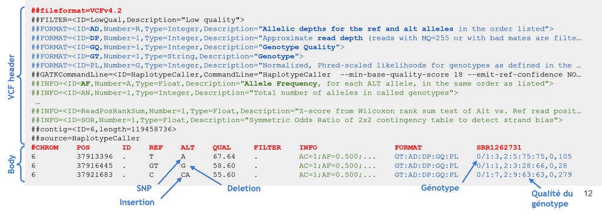

The [GATK page dedicated to the VCF format](https://gatk.broadinstitute.org/hc/en-us/articles/360035531692-VCF-Variant-Call-Format) covers these different sections/columns.

### 3.3 GATK with GVCF output (`--emit-ref-confidence GVCF`)

Reminder:  
The analysis process to obtain a multi-sample VCF is done in several steps and depends on the size of your genome and of your sampling:

- 3-step strategy if you have few samples and/or you work on a small genome:
  - HaplotypeCaller in GVCF mode on each sample
  - CombineGVCFs to obtain a multi-sample GVCF
  - GenotypeGVCFs to convert your multi-sample GVCF file into a multi-sample VCF.

This is the process we are going to see in the practical session.

- 5-step strategy, if you have a large number of samples and/or you work on a large genome:
  - HaplotypeCaller in GVCF mode on each sample (one gVCF per sample, as before)
  - SplitIntervals to split the genome into intervals that will allow the following steps to be parallelised over sub-regions of balanced size.
  - GenomicsDBImport, run on each interval, to import all the individual gVCFs into a GenomicsDB workspace specific to that interval.
  - GenotypeGVCFs, run on each GenomicsDB workspace (one per interval), to produce one multi-sample VCF per interval.
  - [GatherVcfs](https://gatk.broadinstitute.org/hc/en-us/articles/30332005382555-GatherVcfs-Picard) to concatenate the VCFs obtained on each interval from the same set of samples.

💡 **Tip**  
You will find the details of the 5-step procedure in `Annexe2_GenomicsDB.ipynb` for the analysis of a large genome and/or a large cohort.

Back to the 3-step procedure: let's start by creating a new results directory

```bash
mkdir -p Results/Variant_calling/haplotypeCaller_gvcf_mode
```

##### **a) HaplotypeCaller in gvcf mode**

Here, for each sample, we seek to genotype every position of the genome (or of the interval if specified).

Run HaplotypeCaller as before, still on the interval `NC_037329.1:90000000-91140000` to save time:

- on one sample: Results/Variant_calling/BaseRecalibration/milca_40995_recal.bam
- changing the option to `--emit-ref-confidence GVCF`
- changing the output file

💡 **Tip** (reminder)  
As before, add `.gz` to the names of your output gVCF files so that they are automatically compressed.  
In that case, to browse your file use the command `zcat FILE.vcf.gz | more` (or `less`)

```bash
gatk HaplotypeCaller --java-options '-Xmx8G' \
    --input Results/Variant_calling/BaseRecalibration/milca_40995_recal.bam \
    --reference data/genome/Bos_taurus_GCF_002263795.3_ARS-UCD2.0_chr2_chr6.fasta \
    --intervals "NC_037329.1:90000000-91140000" \
    --base-quality-score-threshold 18 \
    --min-base-quality-score 10 \
    --minimum-mapping-quality 20 \
    --sample-ploidy 2 \
    --emit-ref-confidence GVCF \
    --native-pair-hmm-threads 4 \
    --output Results/Variant_calling/haplotypeCaller_gvcf_mode/milca_40995.g.vcf
```

[output not shown]

[output cut: 15 more lines]

```
0 read(s) filtered by: NotSecondaryAlignmentReadFilter
14086 read(s) filtered by: NotDuplicateReadFilter
0 read(s) filtered by: PassesVendorQualityCheckReadFilter
0 read(s) filtered by: NonZeroReferenceLengthAlignmentReadFilter
0 read(s) filtered by: GoodCigarReadFilter
0 read(s) filtered by: WellformedReadFilter
16634 total reads filtered out of 99202 reads processed
14:28:24.928 INFO  ProgressMeter - NC_037329.1:91139810              0.5                  6680          12419.4
14:28:24.928 INFO  ProgressMeter - Traversal complete. Processed 6680 total regions in 0.5 minutes.
14:28:24.963 INFO  VectorLoglessPairHMM - Time spent in setup for JNI call : 0.014064569
14:28:24.963 INFO  PairHMM - Total compute time in PairHMM computeLogLikelihoods() : 7.465664751
14:28:24.963 INFO  SmithWatermanAligner - Total compute time in native Smith-Waterman : 3.96 sec
14:28:24.964 INFO  HaplotypeCaller - Shutting down engine
[August 26, 2026 at 2:28:24 PM CEST] org.broadinstitute.hellbender.tools.walkers.haplotypecaller.HaplotypeCaller done. Elapsed time: 0.54 minutes.
Runtime.totalMemory()=742391808
```

```bash
ls -ltrh Results/Variant_calling/haplotypeCaller_gvcf_mode
```

```
total 12M
-rw-rw----+ 1 mbernard mbernard  11M Aug 26 14:28 milca_40995.g.vcf
-rw-rw----+ 1 mbernard mbernard 357K Aug 26 14:28 milca_40995.g.vcf.idx
```

Let's browse the output file with the `more` or `less` command in your Terminal.

The gVCF file and the VCF file have many similarities. They contain a header, then a file "body" structured in 9 columns, followed by one column per sample.

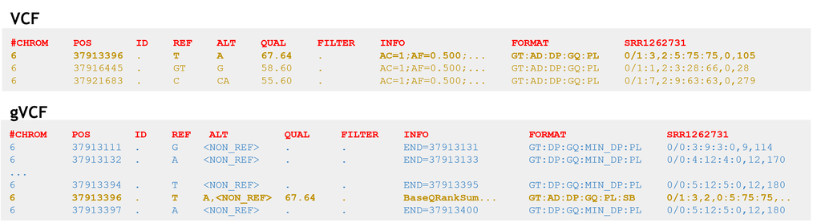

On the GATK website, you will find a [page dedicated to the GVCF format](https://gatk.broadinstitute.org/hc/en-us/articles/360035531812-GVCF-Genomic-Variant-Call-Format)

Header lines start with `##`. To display the first lines of the file "body", use the `grep` command with the `-v` option to ignore this `##` pattern.

```bash
grep -v "##" Results/Variant_calling/haplotypeCaller_gvcf_mode/milca_40995.g.vcf | head
```

```
#CHROM	POS	ID	REF	ALT	QUAL	FILTER	INFO	FORMAT	milca_40995
NC_037329.1	90000000	.	C	<NON_REF>	.	.	END=90000027	GT:DP:GQ:MIN_DP:PL	0/0:6:18:6:0,18,130
NC_037329.1	90000028	.	T	<NON_REF>	.	.	END=90000029	GT:DP:GQ:MIN_DP:PL	0/0:8:24:8:0,24,198
NC_037329.1	90000030	.	A	<NON_REF>	.	.	END=90000045	GT:DP:GQ:MIN_DP:PL	0/0:10:30:10:0,30,229
NC_037329.1	90000046	.	T	<NON_REF>	.	.	END=90000068	GT:DP:GQ:MIN_DP:PL	0/0:12:36:12:0,36,278
NC_037329.1	90000069	.	T	<NON_REF>	.	.	END=90000087	GT:DP:GQ:MIN_DP:PL	0/0:14:42:14:0,42,328
NC_037329.1	90000088	.	T	<NON_REF>	.	.	END=90000091	GT:DP:GQ:MIN_DP:PL	0/0:14:36:14:0,36,540
NC_037329.1	90000092	.	T	<NON_REF>	.	.	END=90000109	GT:DP:GQ:MIN_DP:PL	0/0:12:30:10:0,30,247
NC_037329.1	90000110	.	A	<NON_REF>	.	.	END=90000167	GT:DP:GQ:MIN_DP:PL	0/0:8:24:8:0,24,198
NC_037329.1	90000168	.	A	<NON_REF>	.	.	END=90000185	GT:DP:GQ:MIN_DP:PL	0/0:8:12:4:0,12,99
```

**Question**

- While we are trying to get the genotype at every position, why do we jump from position 90000000 to position 90000028?
- Apart from the positions and the reference alleles (`REF`), what differentiates these lines?

Let's retrieve the gVCFs of the other samples

```bash
cp /shared/projects/2621_eb3in1_2026/atelier_variant_correction/TP_small_variants/Results/Variant_calling/haplotypeCaller_gvcf_mode/milca* \
   /shared/projects/2621_eb3in1_2026/atelier_variant_correction/TP_small_variants/Results/Variant_calling/haplotypeCaller_gvcf_mode/control* \
   Results/Variant_calling/haplotypeCaller_gvcf_mode/.
```

```bash
ls -lh Results/Variant_calling/haplotypeCaller_gvcf_mode
```

```
total 44M
-rw-rw----+ 1 mbernard mbernard 9.2M Aug 26 14:29 control_41011.g.vcf
-rw-rw----+ 1 mbernard mbernard 357K Aug 26 14:29 control_41011.g.vcf.idx
-rw-rw----+ 1 mbernard mbernard  11M Aug 26 14:29 control_41012.g.vcf
-rw-rw----+ 1 mbernard mbernard 357K Aug 26 14:29 control_41012.g.vcf.idx
-rw-rw----+ 1 mbernard mbernard  10M Aug 26 14:29 milca_40995.g.vcf
-rw-rw----+ 1 mbernard mbernard 357K Aug 26 14:29 milca_40995.g.vcf.idx
-rw-rw----+ 1 mbernard mbernard  12M Aug 26 14:29 milca_40998.g.vcf
-rw-rw----+ 1 mbernard mbernard 357K Aug 26 14:29 milca_40998.g.vcf.idx
```

##### **b) CombineGVCFs**

This second step consists in aggregating the samples, still over all the positions of the genome (or of the interval).  
It produces a multi-sample gVCF file.

For CombineGVCFs, the command pattern is:

```
Usage : gatk CombineGVCFs --java-options '-Xmx8G' \
   --reference reference.fasta \
   --variant sample1.g.vcf.gz \
   --variant sample2.g.vcf.gz \
   --output cohort.g.vcf.gz
```

The only option we are interested in is:

- `--intervals` : One or more genomic intervals over which to operate This argument may be specified 0 or more times, format: `CHR:start-stop`

Run CombineGVCFs on our 4 samples and on the interval `NC_037329.1:90000000-91140000`.

```bash
gatk CombineGVCFs --java-options '-Xmx8G' \
    --variant   Results/Variant_calling/haplotypeCaller_gvcf_mode/milca_40995.g.vcf \
    --variant   Results/Variant_calling/haplotypeCaller_gvcf_mode/milca_40998.g.vcf \
    --variant   Results/Variant_calling/haplotypeCaller_gvcf_mode/control_41011.g.vcf \
    --variant   Results/Variant_calling/haplotypeCaller_gvcf_mode/control_41012.g.vcf \
    --reference data/genome/Bos_taurus_GCF_002263795.3_ARS-UCD2.0_chr2_chr6.fasta \
    --intervals "NC_037329.1:90000000-91140000" \
    --output    Results/Variant_calling/haplotypeCaller_gvcf_mode/4samples_selected_region.g.vcf
```

[output not shown]

```bash
ls -lrth Results/Variant_calling/haplotypeCaller_gvcf_mode
```

```
total 100M
-rw-rw----+ 1 mbernard mbernard 357K Aug 26 14:29 control_41011.g.vcf.idx
-rw-rw----+ 1 mbernard mbernard 9.2M Aug 26 14:29 control_41011.g.vcf
-rw-rw----+ 1 mbernard mbernard  11M Aug 26 14:29 control_41012.g.vcf
-rw-rw----+ 1 mbernard mbernard 357K Aug 26 14:29 control_41012.g.vcf.idx
-rw-rw----+ 1 mbernard mbernard  10M Aug 26 14:29 milca_40995.g.vcf
-rw-rw----+ 1 mbernard mbernard 357K Aug 26 14:29 milca_40995.g.vcf.idx
-rw-rw----+ 1 mbernard mbernard  12M Aug 26 14:29 milca_40998.g.vcf
-rw-rw----+ 1 mbernard mbernard 357K Aug 26 14:29 milca_40998.g.vcf.idx
-rw-rw----+ 1 mbernard mbernard  56M Aug 26 14:31 4samples_selected_region.g.vcf
-rw-rw----+ 1 mbernard mbernard 357K Aug 26 14:31 4samples_selected_region.g.vcf.idx
```

You can check the contents of this new gVCF file with the `more` or `less` command in your Terminal, or, as before, with the `grep` command to display the first lines of the file body.

```bash
grep -v "##" Results/Variant_calling/haplotypeCaller_gvcf_mode/4samples_selected_region.g.vcf | head
```

```
#CHROM	POS	ID	REF	ALT	QUAL	FILTER	INFO	FORMAT	control_41011	control_41012	milca_40995	milca_40998
NC_037329.1	90000000	.	C	<NON_REF>	.	.	END=90000001	GT:DP:GQ:MIN_DP:PL	./.:14:36:14:0,36,540	./.:14:42:14:0,42,346	./.:6:18:6:0,18,130	./.:26:72:26:0,72,624
NC_037329.1	90000002	.	T	<NON_REF>	.	.	END=90000010	GT:DP:GQ:MIN_DP:PL	./.:16:42:14:0,42,346	./.:14:42:14:0,42,346	./.:6:18:6:0,18,130	./.:26:72:26:0,72,624
NC_037329.1	90000011	.	A	<NON_REF>	.	.	END=90000012	GT:DP:GQ:MIN_DP:PL	./.:16:42:14:0,42,346	./.:14:42:14:0,42,346	./.:6:18:6:0,18,130	./.:24:60:22:0,60,900
NC_037329.1	90000013	.	C	<NON_REF>	.	.	END=90000016	GT:DP:GQ:MIN_DP:PL	./.:16:48:16:0,48,396	./.:14:42:14:0,42,346	./.:6:18:6:0,18,130	./.:24:60:22:0,60,900
NC_037329.1	90000017	.	G	<NON_REF>	.	.	.	GT:DP:GQ:MIN_DP:PL	./.:16:48:16:0,48,396	./.:12:36:12:0,36,297	./.:6:18:6:0,18,130	./.:24:60:22:0,60,900
NC_037329.1	90000018	.	T	<NON_REF>	.	.	END=90000027	GT:DP:GQ:MIN_DP:PL	./.:16:42:14:0,42,328	./.:12:36:12:0,36,297	./.:6:18:6:0,18,130	./.:24:60:22:0,60,900
NC_037329.1	90000028	.	T	<NON_REF>	.	.	END=90000029	GT:DP:GQ:MIN_DP:PL	./.:16:42:14:0,42,328	./.:12:36:12:0,36,297	./.:8:24:8:0,24,198	./.:24:60:22:0,60,900
NC_037329.1	90000030	.	A	<NON_REF>	.	.	.	GT:DP:GQ:MIN_DP:PL	./.:16:42:14:0,42,328	./.:12:36:12:0,36,297	./.:10:30:10:0,30,229	./.:24:60:22:0,60,900
NC_037329.1	90000031	.	A	<NON_REF>	.	.	END=90000038	GT:DP:GQ:MIN_DP:PL	./.:16:42:14:0,42,328	./.:12:36:12:0,36,297	./.:10:30:10:0,30,229	./.:20:54:18:0,54,426
```

##### **c) GenotypeGVCFs**

This last step consists in detecting the variants and genotyping them across all samples. It produces a multi-sample VCF file.

For GenotypeGVCFs, the command pattern is:

```
Usage : gatk GenotypeGVCFs --java-options '-Xmx8G' \
   --reference reference.fasta \
   --variant multi-sample.g.vcf.gz \
   --output cohort.vcf.gz
```

Les options qui nous intéressent sont :

- `--intervals,-L`:  
  One or more genomic intervals over which to operate This argument may be specified 0 or more times, format : `Chr:start-stop`. Ici `"NC_037329.1:90000000-91140000"`
- `--standard-min-confidence-threshold-for-calling,-stand-call-conf` : Default value: 30.0.  
  The minimum phred-scaled confidence threshold at which variants should be called.

Run GenotypeGVCFs on our multi-sample GVCF and on the interval `NC_037329.1:90000000-91140000`.

```bash
gatk GenotypeGVCFs --java-options '-Xmx8G' \
    --reference data/genome/Bos_taurus_GCF_002263795.3_ARS-UCD2.0_chr2_chr6.fasta  \
    --variant   Results/Variant_calling/haplotypeCaller_gvcf_mode/4samples_selected_region.g.vcf \
    -stand-call-conf 30 \
    --intervals "NC_037329.1:90000000-91140000" \
    --output    Results/Variant_calling/haplotypeCaller_gvcf_mode/4samples_selected_region.vcf
```

[output not shown]

As before, check the contents of your output directory and display the first lines of the body of the new vcf file.

```bash
ls -lrth Results/Variant_calling/haplotypeCaller_gvcf_mode
```

```
total 102M
-rw-rw----+ 1 mbernard mbernard 357K Aug 26 14:29 control_41011.g.vcf.idx
-rw-rw----+ 1 mbernard mbernard 9.2M Aug 26 14:29 control_41011.g.vcf
-rw-rw----+ 1 mbernard mbernard  11M Aug 26 14:29 control_41012.g.vcf
-rw-rw----+ 1 mbernard mbernard 357K Aug 26 14:29 control_41012.g.vcf.idx
-rw-rw----+ 1 mbernard mbernard  10M Aug 26 14:29 milca_40995.g.vcf
-rw-rw----+ 1 mbernard mbernard 357K Aug 26 14:29 milca_40995.g.vcf.idx
-rw-rw----+ 1 mbernard mbernard  12M Aug 26 14:29 milca_40998.g.vcf
-rw-rw----+ 1 mbernard mbernard 357K Aug 26 14:29 milca_40998.g.vcf.idx
-rw-rw----+ 1 mbernard mbernard  56M Aug 26 14:31 4samples_selected_region.g.vcf
-rw-rw----+ 1 mbernard mbernard 357K Aug 26 14:31 4samples_selected_region.g.vcf.idx
-rw-rw----+ 1 mbernard mbernard 2.1M Aug 26 14:37 4samples_selected_region.vcf
-rw-rw----+ 1 mbernard mbernard 179K Aug 26 14:37 4samples_selected_region.vcf.idx
```

```bash
grep -v '##' Results/Variant_calling/haplotypeCaller_gvcf_mode/4samples_selected_region.vcf | head
```

```
#CHROM	POS	ID	REF	ALT	QUAL	FILTER	INFO	FORMAT	control_41011	control_41012	milca_40995	milca_40998
NC_037329.1	90000329	.	C	A	226.62	.	AC=2;AF=0.250;AN=8;BaseQRankSum=0.00;DP=54;ExcessHet=0.6695;FS=0.000;MLEAC=2;MLEAF=0.250;MQ=60.00;MQRankSum=0.00;QD=6.30;ReadPosRankSum=-1.640e-01;SOR=0.781	GT:AD:DP:GQ:PL	0/1:10,6:16:99:100,0,199	0/1:12,8:20:99:138,0,237	0/0:2,0:2:6:0,6,49	0/0:16,0:16:17:0,17,315
NC_037329.1	90000582	.	T	C	72.75	.	AC=1;AF=0.125;AN=8;BaseQRankSum=0.00;DP=66;ExcessHet=0.0000;FS=11.875;MLEAC=1;MLEAF=0.125;MQ=60.00;MQRankSum=0.00;QD=3.31;ReadPosRankSum=1.81;SOR=0.010	GT:AD:DP:GQ:PL	0/0:8,0:8:24:0,24,198	0/1:16,6:22:82:82,0,330	0/0:14,0:14:42:0,42,328	0/0:22,0:22:60:0,60,525
NC_037329.1	90000805	.	C	T	473.44	.	AC=4;AF=0.500;AN=8;BaseQRankSum=0.00;DP=34;ExcessHet=0.3892;FS=1.720;MLEAC=4;MLEAF=0.500;MQ=59.59;MQRankSum=0.00;QD=16.91;ReadPosRankSum=1.43;SOR=0.407	GT:AD:DP:GQ:PL	0/1:4,2:6:31:31,0,81	1/1:0,10:10:30:247,30,0	0/1:2,10:12:14:211,0,14	0/0:6,0:6:18:0,18,148
NC_037329.1	90000866	.	T	TCC	216.01	.	AC=2;AF=0.250;AN=8;BaseQRankSum=0.00;DP=28;ExcessHet=0.6695;FS=2.027;MLEAC=2;MLEAF=0.250;MQ=57.25;MQRankSum=0.030;QD=15.43;ReadPosRankSum=1.38;SOR=1.329	GT:AD:DP:GQ:PL	0/1:2,2:4:78:78,0,78	0/1:6,4:10:99:150,0,240	0/0:8,0:8:24:0,24,179	0/0:6,0:6:18:0,18,148
NC_037329.1	90001544	.	T	C	275.09	.	AC=4;AF=0.500;AN=8;DP=40;ExcessHet=0.0000;FS=0.000;MLEAC=4;MLEAF=0.500;MQ=60.00;QD=22.92;SOR=1.445	GT:AD:DP:GQ:PL	1/1:0,4:4:12:99,12,0	1/1:0,8:8:24:198,24,0	0/0:16,0:16:48:0,48,377	0/0:10,0:10:30:0,30,247
NC_037329.1	90002096	.	A	AC	356.96	.	AC=2;AF=0.250;AN=8;BaseQRankSum=0.00;DP=54;ExcessHet=0.6695;FS=5.469;MLEAC=2;MLEAF=0.250;MQ=60.00;MQRankSum=0.00;QD=11.90;ReadPosRankSum=0.967;SOR=1.363	GT:AD:DP:GQ:PGT:PID:PL:PS	0|1:10,10:20:99:0|1:90002096_A_AC:349,0,349:90002096	0|1:8,2:10:20:0|1:90002096_A_AC…
NC_037329.1	90002098	.	A	T	357	.	AC=2;AF=0.250;AN=8;BaseQRankSum=0.00;DP=52;ExcessHet=0.6695;FS=5.469;MLEAC=2;MLEAF=0.250;MQ=60.00;MQRankSum=0.00;QD=11.90;ReadPosRankSum=0.619;SOR=1.363	GT:AD:DP:GQ:PGT:PID:PL:PS	0|1:10,10:20:99:0|1:90002096_A_AC:349,0,349:90002096	0|1:8,2:10:20:0|1:90002096_A_AC:20,…
NC_037329.1	90002371	.	C	T	102.76	.	AC=1;AF=0.125;AN=8;BaseQRankSum=0.00;DP=46;ExcessHet=0.0000;FS=2.463;MLEAC=1;MLEAF=0.125;MQ=60.00;MQRankSum=0.00;QD=8.56;ReadPosRankSum=-9.350e-01;SOR=1.144	GT:AD:DP:GQ:PL	0/1:6,6:12:99:112,0,112	0/0:8,0:8:24:0,24,179	0/0:8,0:8:24:0,24,179	0/0:16,0:16:42:0,42,630
NC_037329.1	90002754	.	A	G	202	.	AC=2;AF=0.250;AN=8;BaseQRankSum=0.00;DP=64;ExcessHet=0.6695;FS=10.358;MLEAC=2;MLEAF=0.250;MQ=60.00;MQRankSum=0.00;QD=5.94;ReadPosRankSum=1.58;SOR=1.671	GT:AD:DP:GQ:PL	0/1:10,6:16:99:100,0,199	0/1:10,8:18:99:114,0,194	0/0:12,0:12:36:0,36,297	0/0:18,0:18:54:0,54,445
```

**Question**

- What type of variant is detected at position 90000866?
- Among the genotypes, we observe the notations `0/1` and `0|1`. What does this mean? [(hint)](https://gatk.broadinstitute.org/hc/en-us/articles/360050354712-What-is-physical-phasing)

### 3.4 Brief comparison

The annotation step that follows will give us many details on the number and type of variants we have been able to detect.

Here, let's simply check the number of variants (number of lines) included in each of our callings (1-step VCF mode or 3-step gVCF mode).

As a reminder, VCFs contain many header lines starting with `#`. To get the number of variants we can:

- search for all lines that do not contain `#` with the `grep` command
- count the number of remaining lines with the `wc -l` command

```bash
grep -v "#" Results/Variant_calling/haplotypeCaller_vcf_mode/4samples_selected_region.vcf |wc -l

grep -v "#" Results/Variant_calling/haplotypeCaller_gvcf_mode/4samples_selected_region.vcf |wc -l
```

```
4272
6653
```

## IV - Variant Annotation

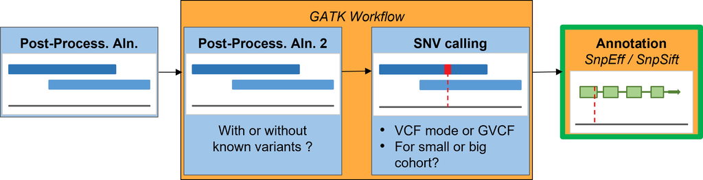

The goal of this annotation is to add biological information to the variants:

- are these variants already known?
- what do we know about the regions in which they are located? This is called **structural annotation**.

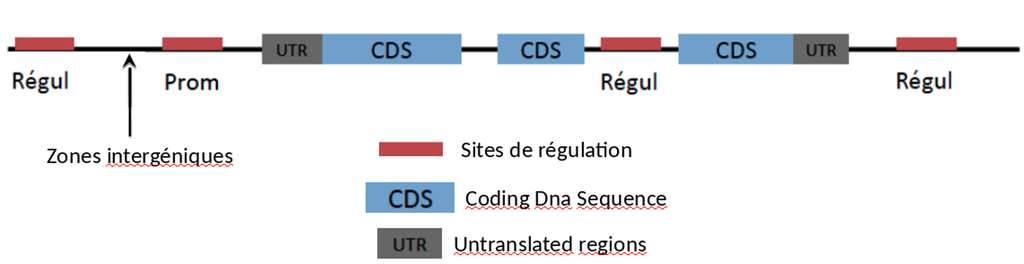

The goal of this annotation is to add biological information to the variants:

- are these variants already known?
- what do we know about the regions in which they are located? This is called **structural annotation**.
- can we predict the impact of each allele? This is called **functional annotation**.

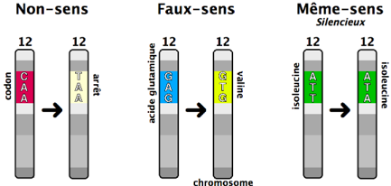

Several tools and variant databases can be used to perform this annotation. These include:

- [Ensembl Variant Effect Predictor](https://jun2026.archive.ensembl.org/info/docs/tools/vep/index.html) (Ensembl VEP)
- the [SnpEff/SnpSift](https://pcingola.github.io/SnpEff/) tool suite

For this practical session, we focus on the SnpEff / SnpSift tool suite:

- [SnpEff](https://pcingola.github.io/SnpEff/snpeff/introduction/) predicts the functional effect of variants: from a VCF and a genomic annotation database (positions of genes, exons, introns, transcripts), it determines for each variant which genic context it falls in, and predicts its impact on the protein. This functional annotation is added to the INFO field of each variant.
- [SnpSift](https://pcingola.github.io/SnpEff/snpsift/introduction/) is the companion tool for filtering, manipulation and additional annotation. It can filter variants using logical expressions on any INFO/FORMAT field, and cross them with known annotation databases.

Let's load the first module, SnpEff, and create a new results directory.

```bash
module load snpeff/5.2
mkdir Results/Variant_annotation/
```

### 1. Building the annotation database

To annotate variants, SnpEff needs a reference database of the genic context of the studied genome.

Many genomes (> 20,000) are already indexed.  
You can find the list with the `snpEff databases` command followed by the `grep` command to sub-select lines with a keyword, here (`Bos_taurus`).

```bash
snpEff databases | grep Bos_taurus
```

```
ARS-UCD1.2.105                                              	Bos_taurus                                                  	          	                              	[https://snpeff-public.s3.amazonaws.com/databases/v5_2/snpEff_v5_2_ARS-UCD1.2.105.zip, https://snpeff-public.s3.amazonaws.com/databases/…
ARS-UCD1.2.99                                               	Bos_taurus                                                  	          	                              	[https://snpeff-public.s3.amazonaws.com/databases/v5_2/snpEff_v5_2_ARS-UCD1.2.99.zip, https://snpeff-public.s3.amazonaws.com/databases/v…
UMD3.1.75                                                   	Bos_taurus                                                  	          	                              	[https://snpeff-public.s3.amazonaws.com/databases/v5_2/snpEff_v5_2_UMD3.1.75.zip, https://snpeff-public.s3.amazonaws.com/databases/v5_0/…
UOA_Angus_1.105                                             	Bos_taurus_hybrid                                           	          	                              	[https://snpeff-public.s3.amazonaws.com/databases/v5_2/snpEff_v5_2_UOA_Angus_1.105.zip, https://snpeff-public.s3.amazonaws.com/databases…
UOA_Angus_1.99                                              	Bos_taurus_hybrid                                           	          	                              	[https://snpeff-public.s3.amazonaws.com/databases/v5_2/snpEff_v5_2_UOA_Angus_1.99.zip, https://snpeff-public.s3.amazonaws.com/databases/…
```

If your genome exists, you can use the `snpEff download` command

The command pattern is:

```
Usage: snpEff download [options] genome_version
```

and the option you are interested in is:

- `-dataDir` : to specify where you want to store the database.

⚠️ **Warning**  
Use an absolute path for this parameter, otherwise it will be relative to the configuration file⚠️

example:

```
snpEff download -dataDir /shared/projects/2621_eb3in1_2026/atelier_variant/TP_small_variants/data/genome/snpeff_db ARS-UCD1.2.105
# or
snpEff download -dataDir `pwd`/data/genome/snpeff_db ARS-UCD1.2.105
```

The ARS-UCD2.0 version of the cattle genome is not available. We therefore need to build our own reference database, at a minimum from:

- the fasta file of your genome (`Bos_taurus_GCF_002263795.3_ARS-UCD2.0_chr2_chr6.fasta`)
- the GFF annotation file (`Bos_taurus_GCF_002263795.3_ARS-UCD2.0_chr2_chr6.gff`).

Display the first lines of these files with `head` and/or `grep -v "#"`.

```bash
head data/genome/Bos_taurus_GCF_002263795.3_ARS-UCD2.0_chr2_chr6.fasta
```

```
>NC_037329.1
TCAGTGCATGATCTTGCCAATGATCAGTGCATGATCAGCCCACGTATTCACGTGCACGCA
CAGTCACGTGATCAATGTATGATCAGCTTCGTGATCAGTGCATGATTAGTTACGTGATCA
ATGTATGATTAGCCAAGTAATCAGTGTATGCACAGTCACGTGATCAGTGTATGATCAGCC
ACGTGACCAGTGCATGATCAGTCACGAGATCAGTGCATGATCAGCCATAGGATCAGTGCA
TGATAGCCATGTGATCAGTGTATGATAGCTACGTGATCAGTGCATGATCAGCCACGTAAT
CAGTGCCTGATCAGCCACGTGATCACTGTATGATCAGCCACGTGATCAGTGCATGTGCAA
TCACGTGATCAGTGTATGATCAGCCAATTGTTCAGTGCATGATAGACAAGTTATCAATGC
ATGATAGCTACGTGATCAGTGCATGCTCAGTCACATGAGCAGTGCATGCACAGTCACGTG
ATCAGTGTATGATCAGCCACATGATCAGTGCATGATCCGCAACGTCATTAGTGCATGATC
```

```bash
# comment lines start with "#"
# grep -v selects the lines that do not contain the keyword given next
grep -v "#" data/genome/Bos_taurus_GCF_002263795.3_ARS-UCD2.0_chr2_chr6.gff | head
```

```
NC_037329.1	RefSeq	region	1	136231102	.	+	.	ID=NC_037329.1:1..136231102;Dbxref=taxon:9913;Name=2;breed=Hereford;chromosome=2;gbkey=Src;genome=chromosome;isolate=L1 Dominette 01449 registration number 42190680;mol_type=genomic DNA;sex=female;tissue-type=left lung
NC_037329.1	Curated Genomic	pseudogene	261597	262534	.	-	.	ID=gene-OR10AG84P;Dbxref=GeneID:104971094,VGNC:VGNC:100370;Name=OR10AG84P;description=olfactory receptor family 10 subfamily AG member 84%2C pseudogene;gbkey=Gene;gene=OR10AG84P;gene_biotype=pseudogene;pseudo=true
NC_037329.1	Curated Genomic	pseudogene	279076	279971	.	+	.	ID=gene-OR5T24P;Dbxref=GeneID:107132231,VGNC:VGNC:101632;Name=OR5T24P;description=olfactory receptor family 5 subfamily T member 24%2C pseudogene;gbkey=Gene;gene=OR5T24P;gene_biotype=pseudogene;pseudo=true
NC_037329.1	Curated Genomic	pseudogene	292154	292974	.	-	.	ID=gene-OR10AG85P;Dbxref=GeneID:107132232,VGNC:VGNC:100371;Name=OR10AG85P;description=olfactory receptor family 10 subfamily AG member 85%2C pseudogene;gbkey=Gene;gene=OR10AG85P;gene_biotype=pseudogene;pseudo=true
NC_037329.1	Curated Genomic	pseudogene	306065	307026	.	-	.	ID=gene-OR5F2EP;Dbxref=GeneID:784948,VGNC:VGNC:101554;Name=OR5F2EP;description=olfactory receptor family 5 subfamily F member 2E%2C pseudogene;gbkey=Gene;gene=OR5F2EP;gene_biotype=pseudogene;pseudo=true
NC_037329.1	BestRefSeq%2CGnomon	gene	315116	382536	.	+	.	ID=gene-LGSN;Dbxref=BGD:BT17181,GeneID:538526,VGNC:VGNC:30863;Name=LGSN;description=lengsin%2C lens protein with glutamine synthetase domain;gbkey=Gene;gene=LGSN;gene_biotype=protein_coding;gene_synonym=GLULD1
NC_037329.1	Gnomon	mRNA	315116	382532	.	+	.	ID=rna-XM_059875859.1;Parent=gene-LGSN;Dbxref=GeneID:538526,GenBank:XM_059875859.1,BGD:BT17181,VGNC:VGNC:30863;Name=XM_059875859.1;experiment=COORDINATES: polyA evidence [ECO:0006239];gbkey=mRNA;gene=LGSN;model_evidence=Supporting evidence includes similar…
NC_037329.1	Gnomon	exon	315116	315176	.	+	.	ID=exon-XM_059875859.1-1;Parent=rna-XM_059875859.1;Dbxref=GeneID:538526,GenBank:XM_059875859.1,BGD:BT17181,VGNC:VGNC:30863;experiment=COORDINATES: polyA evidence [ECO:0006239];gbkey=mRNA;gene=LGSN;product=lengsin%2C lens protein with glutamine synthetase d…
NC_037329.1	Gnomon	exon	368069	368266	.	+	.	ID=exon-XM_059875859.1-2;Parent=rna-XM_059875859.1;Dbxref=GeneID:538526,GenBank:XM_059875859.1,BGD:BT17181,VGNC:VGNC:30863;experiment=COORDINATES: polyA evidence [ECO:0006239];gbkey=mRNA;gene=LGSN;product=lengsin%2C lens protein with glutamine synthetase d…
NC_037329.1	Gnomon	exon	379100	379266	.	+	.	ID=exon-XM_059875859.1-3;Parent=rna-XM_059875859.1;Dbxref=GeneID:538526,GenBank:XM_059875859.1,BGD:BT17181,VGNC:VGNC:30863;experiment=COORDINATES: polyA evidence [ECO:0006239];gbkey=mRNA;gene=LGSN;product=lengsin%2C lens protein with glutamine synthetase d…
```

and optionally from:

- the CDS fasta file
- the protein fasta file
- gff or bed files of regulatory regions or transcription factor motifs (from Ensembl: https://regulation.ensembl.org/)
- the pdb file of protein interactions (from [PDB](https://www.rcsb.org/) or AlphaFold)
- any other .bed file of regions of interest (these will be used at annotation time)

For more details see the [online documentation](https://pcingola.github.io/SnpEff/snpeff/build_db/#building-a-database).

⚠️ **Warning**  
Some of this information comes from Ensembl, so you must have used an Ensembl reference during your sequence analysis.

Let's start by creating a `snpeff_db` directory in our `data/genome` directory.

```bash
mkdir data/genome/snpeff_db
```

Choose a prefix that will identify your genome in the SnpEff config file and will be used to create the directory that will contain the associated annotation database.

💡 **Tip**  
choose a name that is as explicit as possible, for example here: `Bos_taurus_ARS-UCD2.0_chr2_chr6_manual`

- Copy the original snpEff configuration file (`/shared/software/miniconda_deployment//envs/snpeff-5.2/share/snpeff-5.2-3/snpEff.config`) into your new directory (`data/genome/snpeff_db`)

```bash
cp /shared/software/miniconda_deployment//envs/snpeff-5.2/share/snpeff-5.2-3/snpEff.config data/genome/snpeff_db/snpeff.config
```

Open it with the Jupyter file browser.

Scroll down to the section that tells you how to add a new genome (lines 128 - 131).

```
# For genome version 'ZZZ' the entries look like
#	ZZZ.genome              : Real name for ZZZ (e.g. 'Human')
#	ZZZ.reference           : [Optional] Comma separated list of URL to site/s where information for building ZZZ database was extracted.
#	ZZZ.chrName.codonTable  : [Optional] Define codon table used for chromosome 'chrName' (Default: 'codon.Standard')
```

Add a section after it (for example at line 134) for our genome, replacing `ZZZ` with our prefix `Bos_taurus_ARS-UCD2.0_chr2_chr6_manual`.

ℹ️ **Note**

- the `ZZZ.reference` line indicates where to download the data. This does not concern us
- the `ZZZ.chrName.codonTable` line lets you indicate whether a sequence (`chrName`) of your genome uses different codons (see lines 86 to 122).  
  This is the case, for example, of the mitochondrion. This does not concern us either.

ℹ️ **Note**  
Start your lines with a `#` if you want to add a comment.

For example:

```
#---
# Manual Databases
#---

# Chr2 and 6 of the Bos taurus ARS-UCD2.0 genome
Bos_taurus_ARS-UCD2.0_chr2_chr6_manual.genome : Bovine (ARS-UCD2.0 extracted for the Roscoff practical session)
```

- Create the `<prefix>` directory (i.e. `data/genome/snpeff_db/Bos_taurus_ARS-UCD2.0_chr2_chr6_manual`) to store the SnpEff annotation database

```bash
mkdir -p data/genome/snpeff_db/Bos_taurus_ARS-UCD2.0_chr2_chr6_manual
```

- Copy the genome sequences under the name `sequences.fa` and the annotations under the name `genes.gff` into the previous directory

```bash
cp data/genome/Bos_taurus_GCF_002263795.3_ARS-UCD2.0_chr2_chr6.fasta data/genome/snpeff_db/Bos_taurus_ARS-UCD2.0_chr2_chr6_manual/sequences.fa
cp data/genome/Bos_taurus_GCF_002263795.3_ARS-UCD2.0_chr2_chr6.gff data/genome/snpeff_db/Bos_taurus_ARS-UCD2.0_chr2_chr6_manual/genes.gff
```

Check the contents of the genome folder with the `tree` command

```bash
tree data/genome/snpeff_db
```

```
data/genome/snpeff_db
├── Bos_taurus_ARS-UCD2.0_chr2_chr6_manual
│   ├── genes.gff
│   └── sequences.fa
└── snpeff.config

1 directory, 3 files
```

To build the database, we are going to use the `snpEff build` tool.  
To display the help use the `-h` option or consult the [online documentation](https://pcingola.github.io/SnpEff/snpeff/build_db/#building-a-database).

```bash
snpEff build -h
```

```
snpEff version SnpEff 5.2 (build 2023-09-29 06:17), by Pablo Cingolani
Usage: snpEff build [options] genome_version

Build DB options:

Database format option (default: Auto detect):
	-embl                        : Use Embl format.
	-genbank                     : Use GenBank format.
	-gff2                        : Use GFF2 format (obsolete).
	-gff3                        : Use GFF3 format.
	-gtf22                       : Use GTF 2.2 format.
	-knowngenes                  : Use KnownGenes table from UCSC.
	-refseq                      : Use RefSeq table from UCSC.

Database build options:
	-cellType <type>             : Only build regulation tracks for cellType <type>.
	-maxErrorRate <num>          : Maximum allowed error rate (number between 0.0 and 1.0). Default: 0.05
	-noCheckCds                  : Skip CDS sequences check.
	-noCheckProtein              : Skip Protein sequences check.
	-noStoreSeqs                 : Do not store sequence in binary files. Default: false
	-onlyReg                     : Only build regulation tracks.
	-regSortedByType             : The 'regulation.gff' file is sorted by 'regulation type' instead of sorted by chromosome:pos. Default: false
	-storeSeqs                   : Store sequence in binary files. Default: true

Generic options:
	-c , -config                 : Specify config file
	-configOption name=value     : Override a config file option
	-d , -debug                  : Debug mode (very verbose).
	-dataDir <path>              : Override data_dir parameter from config file.
	-download                    : Download a SnpEff database, if not available locally. Default: true
	-nodownload                  : Do not download a SnpEff database, if not available locally.
	-h , -help                   : Show this help and exit
	-noLog                       : Do not report usage statistics to server
	-q , -quiet                  : Quiet mode (do not show any messages or errors)
	-v , -verbose                : Verbose mode
	-version                     : Show version number and exit
```

The command pattern is:

```
Usage: snpEff build [options] genome_version
```

and the options we are interested in are:

- `-gff3` : which indicates the annotation format (even though there is an auto-detect mode by default)
- `-noCheckCds` : because we do not have a CDS fasta file
- `-noCheckProtein` : because we do not have a protein fasta file
- `-c` : to specify our configuration file
- `-dataDir` : to specify where you want to store the database.

⚠️ **Warning**  
Use an absolute path for this parameter, otherwise it will be relative to the configuration file

- `-v, -verbose` : to get, among other things, a summary of the genic information taken into account.

Apply this pattern to the previously prepared files.

```bash
snpEff build -gff3 -noCheckCds -noCheckProtein -c data/genome/snpeff_db/snpeff.config -dataDir `pwd`/data/genome/snpeff_db -v Bos_taurus_ARS-UCD2.0_chr2_chr6_manual
```

[output not shown]

[output cut: 385 more lines]

```
00:00:07 Caracterizing exons by splicing (stage 2) :
	............................................................................00:00:07 done.
00:00:07 [Optional] Rare amino acid annotations
WARNING_FILE_NOT_FOUND: Rare Amino Acid analysis: Cannot read protein sequence file '/shared/projects/2621_eb3in1_2026/atelier_variant/TP_small_variants/data/genome/snpeff_db/Bos_taurus_ARS-UCD2.0_chr2_chr6_manual/protein.fa', nothing done.
00:00:07 Saving database
00:00:13 Saving sequences for chromosome 'NC_037329.1' to file '/shared/projects/2621_eb3in1_2026/atelier_variant/TP_small_variants/data/genome/snpeff_db/Bos_taurus_ARS-UCD2.0_chr2_chr6_manual/sequence.NC_037329.1.bin'
00:00:26 Saving sequences for chromosome 'NC_037333.1' to file '/shared/projects/2621_eb3in1_2026/atelier_variant/TP_small_variants/data/genome/snpeff_db/Bos_taurus_ARS-UCD2.0_chr2_chr6_manual/sequence.NC_037333.1.bin'
00:00:37 [Optional] Reading regulation elements: GFF
WARNING_FILE_NOT_FOUND: Cannot read optional regulation file '/shared/projects/2621_eb3in1_2026/atelier_variant/TP_small_variants/data/genome/snpeff_db/Bos_taurus_ARS-UCD2.0_chr2_chr6_manual/regulation.gff', nothing done.
00:00:37 [Optional] Reading regulation elements: BED
00:00:37 Cannot find optional regulation dir '/shared/projects/2621_eb3in1_2026/atelier_variant/TP_small_variants/data/genome/snpeff_db/Bos_taurus_ARS-UCD2.0_chr2_chr6_manual/regulation.bed/', nothing done.
00:00:37 [Optional] Reading motifs: GFF
WARNING_FILE_NOT_FOUND: Cannot open PWMs file /shared/projects/2621_eb3in1_2026/atelier_variant/TP_small_variants/data/genome/snpeff_db/Bos_taurus_ARS-UCD2.0_chr2_chr6_manual/pwms.bin. Nothing done
00:00:37 Done
00:00:37 Done.
```

Check the contents of your directory again with the `tree` command.

```bash
tree data/genome/snpeff_db
```

```
data/genome/snpeff_db
├── Bos_taurus_ARS-UCD2.0_chr2_chr6_manual
│   ├── genes.gff
│   ├── sequence.NC_037329.1.bin
│   ├── sequence.NC_037333.1.bin
│   ├── sequences.fa
│   └── snpEffectPredictor.bin
└── snpeff.config

1 directory, 6 files
```

### 2. Annotation with our database

We are now going to annotate our multi-sample VCF file with the `snpEff eff` tool.

To display the help use the `-h` option or consult the [online help](https://pcingola.github.io/SnpEff/snpeff/running/).

```bash
snpEff eff -h
```

```
snpEff version SnpEff 5.2 (build 2023-09-29 06:17), by Pablo Cingolani
Usage: snpEff [eff] [options] genome_version [input_file]


	variants_file                   : Default is STDIN



Options:
	-chr <string>                   : Prepend 'string' to chromosome name (e.g. 'chr1' instead of '1'). Only on TXT output.
	-classic                        : Use old style annotations instead of Sequence Ontology and Hgvs.
	-csvStats <file>                : Create CSV summary file.
	-download                       : Download reference genome if not available. Default: true
	-i <format>                     : Input format [ vcf, bed ]. Default: VCF.
	-fileList                       : Input actually contains a list of files to process.
	-o <format>                     : Ouput format [ vcf, gatk, bed, bedAnn ]. Default: VCF.
	-s , -stats, -htmlStats         : Create HTML summary file.  Default is 'snpEff_summary.html'
	-noStats                        : Do not create stats (summary) file

Results filter options:
	-fi , -filterInterval  <file>   : Only analyze changes that intersect with the intervals specified in this file (you may use this option many times)
	-no-downstream                  : Do not show DOWNSTREAM changes
	-no-intergenic                  : Do not show INTERGENIC changes
	-no-intron                      : Do not show INTRON changes
	-no-upstream                    : Do not show UPSTREAM changes
	-no-utr                         : Do not show 5_PRIME_UTR or 3_PRIME_UTR changes
	-no <effectType>                : Do not show 'EffectType'. This option can be used several times.

Annotations options:
	-cancer                         : Perform 'cancer' comparisons (Somatic vs Germline). Default: false
	-cancerSamples <file>           : Two column TXT file defining 'oringinal \t derived' samples.
	-fastaProt <file>               : Create an output file containing the resulting protein sequences.
	-formatEff                      : Use 'EFF' field compatible with older versions (instead of 'ANN').
	-geneId                         : Use gene ID instead of gene name (VCF output). Default: false
	-hgvs                           : Use HGVS annotations for amino acid sub-field. Default: true
	-hgvsOld                        : Use old HGVS notation. Default: false
	-hgvs1LetterAa                  : Use one letter Amino acid codes in HGVS notation. Default: false
	-hgvsTrId                       : Use transcript ID in HGVS notation. Default: false
	-lof                            : Add loss of function (LOF) and Nonsense mediated decay (NMD) tags.
	-noHgvs                         : Do not add HGVS annotations.
```

[output cut: 28 more lines]

```
	-noGenome                    : Do not load any genomic database (e.g. annotate using custom files).
	-noExpandIUB                 : Disable IUB code expansion in input variants
	-noInteraction               : Disable inteaction annotations
	-noMotif                     : Disable motif annotations.
	-noNextProt                  : Disable NextProt annotations.
	-onlyReg                     : Only use regulation tracks.
	-onlyProtein                 : Only use protein coding transcripts. Default: false
	-onlyTr <file.txt>           : Only use the transcripts in this file. Format: One transcript ID per line.
	-reg <name>                  : Regulation track to use (this option can be used add several times).
	-ss , -spliceSiteSize <int>  : Set size for splice sites (donor and acceptor) in bases. Default: 2
	-spliceRegionExonSize <int>  : Set size for splice site region within exons. Default: 3 bases
	-spliceRegionIntronMin <int> : Set minimum number of bases for splice site region within intron. Default: 3 bases
	-spliceRegionIntronMax <int> : Set maximum number of bases for splice site region within intron. Default: 8 bases
	-strict                      : Only use 'validated' transcripts (i.e. sequence has been checked). Default: false
	-ud , -upDownStreamLen <int> : Set upstream downstream interval length (in bases)
```

The command pattern is:

```
Usage: snpEff [eff] [options] genome_version [input_file] > output_file
```

and the options we are interested in are:

- `-c` : to specify our configuration file
- `-dataDir` : to specify where the annotation database is stored.

⚠️ **Warning**  
Use an absolute path for this parameter, otherwise it will be relative to the configuration file

- `-s , -stats, -htmlStats` : to specify the path of the analysis report (HTML format)

Apply this pattern to the multi-sample VCF file and write the result (a VCF) to your output directory `Results/Variant_annotation/`

```bash
snpEff eff -c data/genome/snpeff_db/snpeff.config \
           -dataDir `pwd`/data/genome/snpeff_db \
           -s Results/Variant_annotation/snpeff_report.html \
           Bos_taurus_ARS-UCD2.0_chr2_chr6_manual \
           Results/Variant_calling/haplotypeCaller_gvcf_mode/4samples_selected_region.vcf > Results/Variant_annotation/4samples_selected_region_annotated.vcf
```

Let's check the contents of our output directory.

```bash
ls -lrth Results/Variant_annotation/
```

```
total 7.3M
-rw-rw----+ 1 mbernard mbernard 7.0M Aug 26 14:43 4samples_selected_region_annotated.vcf
-rw-rw----+ 1 mbernard mbernard 269K Aug 26 14:43 snpeff_report.html
-rw-rw----+ 1 mbernard mbernard  11K Aug 26 14:43 snpeff_report.genes.txt
```

SnpEff produces a new VCF with a new `ANN` field in the `INFO` column.  
This field gathers a lot of information per alternative allele and per impacted gene.

Let's look at the change on the first variant before and after annotation.

```bash
grep -v '^#' Results/Variant_calling/haplotypeCaller_gvcf_mode/4samples_selected_region.vcf | head -n1
```

[output not shown]

```bash
grep -v '^#' Results/Variant_annotation/4samples_selected_region_annotated.vcf | head -n1
```

```
NC_037329.1	90000329	.	C	A	226.62	.	AC=2;AF=0.250;AN=8;BaseQRankSum=0.00;DP=54;ExcessHet=0.6695;FS=0.000;MLEAC=2;MLEAF=0.250;MQ=60.00;MQRankSum=0.00;QD=6.30;ReadPosRankSum=-1.640e-01;SOR=0.781;ANN=A|intron_variant|MODIFIER|exon-NM_001206233.1-1|GENE_exon-NM_001206233.1-1|transcript|rna-NM_001206233.…
```

[The online documentation](https://pcingola.github.io/SnpEff/snpeff/inputoutput/#ann-field-vcf-output-files) gives a detailed description of this `ANN` field,  
and a [dedicated section](https://pcingola.github.io/SnpEff/snpeff/inputoutput/#variant-annotaiton-details) lists the different types of effects and their impact "strength".

To make exploring the results easier, download the `snpeff_report.html` file and let's explore it together.

**Question**  
If you had to prioritise the exploration of these variants, which ones would you choose?

### 3. Selecting variants of interest

Exploring the annotated VCF as it is does not seem easy.

For this we are going to use a new tool, `SnpSift`, and its `filter` command.

Load the dedicated module and display the help of the `SnpSift` command with the `-h` option.

```bash
module load snpsift/4.3.1t
SnpSift filter -h
```

```
SnpSift version 4.3t (build 2017-11-24 10:18), by Pablo Cingolani

Usage: java -jar SnpSift.jar filter [options] 'expression' [input.vcf]
Options:
	-a|--addFilter <str>  : Add a string to FILTER VCF field if 'expression' is true. Default: '' (none)
	-e|--exprFile <file>  : Read expression from a file
	-f|--file <input.vcf> : VCF input file. Default: STDIN
	-i|--filterId <str>   : ID for this filter (##FILTER tag in header and FILTER VCF field). Default: 'SnpSift'
	-n|--inverse          : Inverse. Show lines that do not match filter expression
	-p|--pass             : Use 'PASS' field instead of filtering out VCF entries
	-r|--rmFilter <str>   : Remove a string from FILTER VCF field if 'expression' is true (and 'str' is in the field). Default: '' (none)
	-s|--set <file>       : Create a SET using 'file'
	--errMissing          : Error is a field is missing. Default: false
	--format <format>     : SnpEff format version: {2, 3}. Default: Auto
	--galaxy              : Used from Galaxy (expressions have been sanitized).
```

The command pattern is:

```
Usage:
    java -jar SnpSift.jar filter [options] 'expression' [input.vcf] > output.vcf
    # or more simply
    SnpSift filter [options] 'expression' [input.vcf] > output.vcf
```

SnpSift uses an expression system to select variants. The expression can involve any of the VCF columns: `CHROM`, `POS`, `ID`, `REF`, `ALT`, `QUAL`, `FILTER`, `INFO`, `FORMAT` but also all the sub-fields, typically the `ANN` sub-field of the `INFO` column or the genotypes.

[The online documentation](https://pcingola.github.io/SnpEff/snpsift/filter/) gives many examples.

For example, let's select all variants that cause an amino acid change (`missense_variant`)

```bash
SnpSift filter \
    "ANN[0].EFFECT has 'missense_variant'" \
    Results/Variant_annotation/4samples_selected_region_annotated.vcf \
    > Results/Variant_annotation/4samples_selected_region_missens_variant.vcf
```

Let's count the number of selected variants (selecting lines that do not start with "#" and counting)

```bash
grep -v "#" Results/Variant_annotation/4samples_selected_region_missens_variant.vcf | wc -l
```

```
36
```

As a reminder, we have:

- 2 samples carrying the "milca" mutation: 40995 and 40998
- 2 non-carrier samples: 41011 and 41012

We may then want to filter the variants that are homozygous reference in the non-carriers (0/0), and variant in the carriers (0/1 or 1/1).

```bash
SnpSift filter  \
 'isVariant( GEN[milca_40995] ) & isVariant( GEN[milca_40998] ) & isRef( GEN[control_41011] ) & isRef( GEN[control_41012] ) ' \
 Results/Variant_annotation/4samples_selected_region_missens_variant.vcf \
 > Results/Variant_annotation/4samples_selected_region_missens_variant_milca_mutation.vcf
```

Count the number of selected variants.

```bash
grep -v "#" Results/Variant_annotation/4samples_selected_region_missens_variant_milca_mutation.vcf | wc -l
```

```
1
```

Let's look at the contents of the file.

ℹ️ **Note**  
The `datamash` tool suite performs basic numerical, textual and statistical operations on input text data files. We will use it here to transpose columns into rows.

```bash
module load datamash/1.9
grep -v "##" Results/Variant_annotation/4samples_selected_region_missens_variant_milca_mutation.vcf | datamash transpose
```

```
#CHROM	NC_037329.1
POS	90572569
ID	.
REF	G
ALT	C
QUAL	612.0
FILTER	.
INFO	AC=2;AF=0.250;AN=8;BaseQRankSum=1.19;DP=72;ExcessHet=0.6695;FS=5.632;MLEAC=2;MLEAF=0.250;MQ=60.00;MQRankSum=0.00;QD=19.13;ReadPosRankSum=0.410;SOR=0.138;ANN=C|missense_variant|MODERATE|exon-NM_001144091.1-1|GENE_exon-NM_001144091.1-1|transcript|rna-NM_001144091.1|protein_coding|1/1|c.1241G>C|p.…
FORMAT	GT:AD:DP:GQ:PGT:PID:PL:PS
milca_40995	0|1:8,8:16:99:0|1:90572567_G_T:312,0,312:90572567
milca_40998	0|1:8,8:16:99:0|1:90572567_G_T:312,0,290:90572567
control_41011	0/0:20,0:20:48:.:.:0,48,720
control_41012	0/0:18,0:18:54:.:.:0,54,445
```

This mutation was detected in 3.7% of Montbéliarde cattle.  
The authors of [the publication](https://doi.org/10.1111/age.13055) also showed that the position of the variant is extremely conserved across orthologues and paralogues of the FZD gene family, which strengthens the hypothesis of a causal effect of this mutation.

## Conclusion

We have seen:

- Variant calling is sensitive to many experimental and methodological factors
- The GATK tool suite is one of the references and offers an analysis workflow that includes:
  - Recalibration of sequence qualities via `BaseRecalibrator` and `ApplyBQSR`
  - Variant calling, notably with `HaplotypeCaller`
  - Management of large sample cohorts, notably with `CombineGVCFs` and `GenotypeGVCFs`
- Variant annotation includes structural and functional annotation.
- This annotation depends on the known resources linked to your genome (⚠️beware of reference compatibility)

In addition to this material, you have two appendices:

- `Annexe1_Baserecalibration.ipynb` for building a set of "reliable" variants allowing proper use of the base recalibration tools.
- `Annexe2_GenomicsDB.ipynb` for managing large cohorts and/or analyses on large genomes by applying the 5-step calling strategy.